# Project 3

### Load modules

```python
import numpy as np
import math
import pandas
import cv2
import matplotlib.image as mpimg
import matplotlib.pyplot as plt
import os

from sklearn.model_selection import train_test_split
from sklearn.utils import shuffle
#import pre_process_image_pipeline
%matplotlib inline

# Fix error with TF and Keras
import tensorflow as tf
tf.python.control_flow_ops = tf

print('Modules loaded.')
```

```
Modules loaded.
```

### Constants

```python
batch_size = 128
rows = 32
cols = 64
ch = 3
```

### Load and split training data

```python
df = pandas.read_csv('session_data/driving_log.csv', header=0)
df_train, df_test = train_test_split(df, test_size = 0.2, random_state=0)
```

```python
print(df_train.center.iloc[0], df_train.steering.iloc[0])
print(df_train.left.iloc[0], df_train.steering.iloc[0])
print(df_train.right.iloc[0], df_train.steering.iloc[0])
print(df_train.center.iloc[5000], df_train.steering.iloc[5000])
print(df_test.center.iloc[0], df_train.steering.iloc[0])
print(df_test.center.iloc[1000], df_test.steering.iloc[1000])
```

```
/home/tjosh/codes/SDCN/Behavioural_Cloning/simulator-linux/session_data/IMG/center_2017_01_21_00_18_27_893.jpg 0.0
 /home/tjosh/codes/SDCN/Behavioural_Cloning/simulator-linux/session_data/IMG/left_2017_01_21_00_18_27_893.jpg 0.0
 /home/tjosh/codes/SDCN/Behavioural_Cloning/simulator-linux/session_data/IMG/right_2017_01_21_00_18_27_893.jpg 0.0
/home/tjosh/codes/SDCN/Behavioural_Cloning/simulator-linux/session_data/IMG/center_2017_01_21_00_47_13_266.jpg 0.0
/home/tjosh/codes/SDCN/Behavioural_Cloning/simulator-linux/session_data/IMG/center_2017_01_21_00_50_56_399.jpg 0.0
/home/tjosh/codes/SDCN/Behavioural_Cloning/simulator-linux/session_data/IMG/center_2017_01_21_01_15_32_881.jpg 0.0
```

```python
print(len(df_train.center))
print(len(df_test.center))
print(len(df_train.steering))
head, fname = os.path.split(df_train.center.iloc[0])
print(fname)
print('./session_data/IMG/'+fname)
print(cv2.imread('./session_data/IMG/' + fname).shape)
print(df_train.steering.iloc[0])
```

```
27762
6941
27762
center_2017_01_21_00_18_27_893.jpg
./session_data/IMG/center_2017_01_21_00_18_27_893.jpg
(160, 320, 3)
0.0
```

### Data Visulization

```python
sample_images = df_train.center.iloc[0:10]
images = []
print(type(sample_images))
for image in sample_images:
    head, fname = os.path.split(image)
    images.append(mpimg.imread('./session_data/IMG/' + fname))
print(len(images))
```

```
<class 'pandas.core.series.Series'>
10
```

#### 10 images with steering angle from dataset

[figure not shown]

[figure not shown]

[figure not shown]

[figure not shown]

[figure not shown]

[figure not shown]

[figure not shown]

[figure not shown]

[figure not shown]

[figure not shown]

```python
for i in range(10):
    plt.figure()
    image = images[i]
    plt.imshow(image)
    plt.title(df_train.steering.iloc[i])
    cv2.imwrite('output_images/sample_image_'+str(i)+'.jpg', image)
plt.show()
```

#### Histogram of collected steering angles

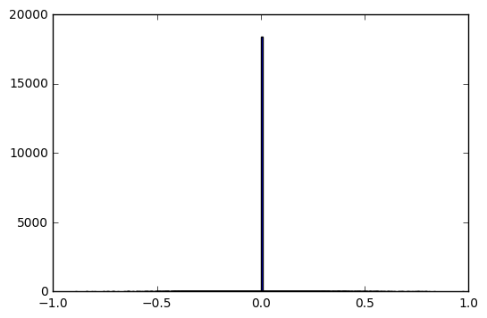

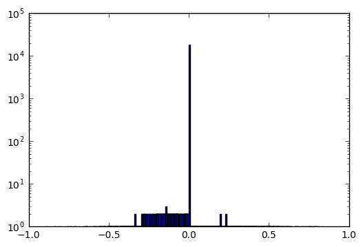

```python
hist = df_train.steering.value_counts()

plt.figure()
plt.bar(hist.index, hist.values, width=0.01)
plt.show()
plt.figure()
fig, ax = plt.subplots()
ax.bar(hist.index, hist.values, width=0.01)
ax.set_yscale('log')
```

### Definitions

```python
def crop(img):
    shape = img.shape
    image = img[math.floor(shape[0]/2.5):shape[0]-25, 0:shape[1]]
    image = cv2.resize(image, (cols, rows), interpolation=cv2.INTER_AREA)
    return image

def shift_image(image, angle, trange):
    rows,cols,ch = image.shape
    x = (trange/2) - int(100*np.random.uniform())
    angle = angle + (x * .004)
    M = np.float32([[1,0,x],[0,1,0]])
    image = cv2.warpAffine(image,M,(cols,rows))
    return image, angle

def flip(img, angle):
    # 50% chance of flipping image on vertical axis
    flip = np.random.randint(100)
    if flip < 50:
        img = cv2.flip(img,1)
        angle = -angle
    return img, angle

def flip_vert(img):
    img = cv2.flip(img,0)
    return img

def change_brightness(img):
    img = cv2.cvtColor(img, cv2.COLOR_BGR2HSV)

    # random scale factor from .25 to 1.25
    a = 0.25 + np.random.uniform()
    scaled = np.zeros_like(img)
    scaled = cv2.convertScaleAbs(img, scaled, a)
    img = cv2.cvtColor(scaled, cv2.COLOR_HSV2BGR)
    return img

def process_img_pipeline(feature_image):
    # crop, change brightness, and convert to RGB
    feature_image = crop(feature_image)
    feature_image = change_brightness(feature_image)
    feature_image = cv2.cvtColor(feature_image, cv2.COLOR_BGR2RGB)
    return feature_image

def normalize_data_pipeline(feature_image, angle):

    # decide if we'll flip it
    feature_image, angle = flip(feature_image, angle)

    # shift the image randomly and adjust steering angle by .004 per pix
    # simulates new positions on the track that the car never actually took
    #feature_image, angle = shift_image(feature_image, angle, 100)

    return feature_image, angle

def batch_data_generator(X_train, y_train, batch_size):
    bx = np.zeros((batch_size, rows, cols, ch), dtype=np.uint8)
    by = np.zeros(batch_size, dtype=np.float)
    i = 0

    while 1:

        # randomly choose left, center, or right image
        idx = np.random.randint(len(y_train))
        angle = y_train.iloc[idx]
        rand = np.random.randint(3)

        if rand == 0:
            head, fname = os.path.split(X_train.left.iloc[idx])
            img = cv2.imread('./session_data/IMG/' + fname)
            angle += .15
        elif rand == 1:
            head, fname = os.path.split(X_train.center.iloc[idx])
            img = cv2.imread('./session_data/IMG/' + fname)
        else:
            head, fname = os.path.split(X_train.right.iloc[idx])
            img = cv2.imread('./session_data/IMG/' + fname)
            angle -= .15

        # new udacity sim only recorded center
        if img is not None:
            # normalize/augment our data. flip, shift, etc.
            img, angle = normalize_data_pipeline(img, angle)
            img = process_img_pipeline(img)
            bx[i] = img
            by[i] = angle
            i += 1
        else:
            pass

        if i >= batch_size-1:
            yield bx, by
            # reset
            bx = np.zeros((batch_size, rows, cols, ch), dtype=np.uint8)
            by = np.zeros(batch_size, dtype=np.float)
            i = 0
```

```python
fname = df_train.center.iloc[804]
print(fname)

img = cv2.imread(fname)
img = cv2.imread('IMG/right_2016_12_01_13_36_53_210.jpg')
img = process_img_pipeline(img)
plt.imshow(img)
```

### Test Generator

```python
model = get_model()

x_proc = np.zeros((batch_size, rows, cols, ch), dtype=np.uint8)
y_proc = np.zeros(batch_size, dtype=np.float)
i = 0


#while i < batch_size:
gen = batch_data_generator(df_train, df_train.steering, batch_size)
for x, y in gen:
    x_proc[i] = x[i]
    y_proc[i] = y[i]
    i += 1
    if i >= 1:
        break

print(x_proc.shape, y_proc.shape, i)
plt.imshow(x_proc[0])
```

### Comma.ai Regression Model

```python
from keras.models import Sequential
from keras.layers import Dense, Activation, Flatten, Dropout, Lambda, ELU, ZeroPadding2D, MaxPooling2D
from keras.layers.convolutional import Convolution2D
# A regression model from comma.ai
def get_model(time_len=1):
    model = Sequential()
    model.add(Lambda(lambda x: x/127.5 - 1.0,
            input_shape=(rows, cols, ch),
            output_shape=(rows, cols, ch)))
    model.add(Convolution2D(16, 8, 8, subsample=(4, 4), border_mode="same"))
    model.add(ELU())
    model.add(Convolution2D(32, 5, 5, subsample=(2, 2), border_mode="same"))
    model.add(ELU())
    model.add(Convolution2D(64, 5, 5, subsample=(2, 2), border_mode="same"))
    model.add(ELU())
    model.add(Convolution2D(128, 5, 5, subsample=(2, 2), border_mode="same"))
    model.add(Dropout(.5))
    model.add(Flatten())
    model.add(Dropout(.5))
    model.add(ELU())
    model.add(Dense(512))
    model.add(Dropout(.2))
    model.add(ELU())
    model.add(Dense(1))

    model.compile(optimizer="adam", loss="mse", lr=0.0001)
    return model

#     if weights_path:
#         model.load_weights(weights_path)

#    return model
```

### Training

```python
model = get_model()
n_samples_per_epoch = len(df_train.steering)
train_gen = batch_data_generator(df_train, df_train.steering, batch_size)
valid_gen = batch_data_generator(df_test, df_test.steering, batch_size)
history = model.fit_generator(train_gen,
                                  validation_data=valid_gen,
                                  samples_per_epoch=n_samples_per_epoch,
                                  nb_val_samples=n_samples_per_epoch,
                                  nb_epoch=9)
print("training complete!")
```

[output not shown]

## Testing

Once you've picked out your best model, it's time to test it.

Save the model to json and the weights to h5 and run the simulator

```python
#from models import model_from_json

json = model.to_json()
model.save_weights("../model.h5")
with open("../model.json", mode="w+") as f:
    f.write(json)
    f.close()
print("model saved")
```

My project includes the following files:

- model.py containing the script to create and train the model
- drive.py for driving the car in autonomous mode which has been slightly modified so pleasae use this one and not your own
- model.h5 containing a trained convolutional neural network
- this readme.md

model.py contain the code for preprocess and training the nearual network

### Model Archetecture and Strategy

#### Training Data

Initial I was using the data given by Udacity. However, I also came across a much larger dataset through the slack channel, and ended up training on that one. Training off the larger dataset helped the model finally train well enough to drive autonomously around the track.

#### Model Performance

I've spent a great deal of time trying to implement different models like comma.ai, VGG16, Lenet-5, and custom. For this submission my car is able to make it around the track on some runs, but not every one. I believe next steps in this model would be finetuning, but I'm not sure what would be the best start. I don't think I need more data. That means I could try tuning hyperparamters that feed into the model. The first thing I might try next if I have time would be to increaase the starting image size (gain more parameters) and increase the number of training epoch by 2x.

#### Other Design Approach Notes

I started with the comma.ai model because it trained much faster than the VGG16 and I wanted a faster feedback loop. The greatest challenge in the beginning was keeping all the moving parts organized. This type of project requires very clean, organized code. Something that I know I could still improve on. Eventually, I got the car driving past the first hard curve, but I was stuck for a very long time on the soft curve right after that. So I gathered additional training data for that partiular curve, and also gathered additional recovery data.

#### Preprocessing

This project preprocess the images in the following ways:

- crop the top and bottom of the imgage to focus on the road
- flip the image on the vertical axis 50% of the time
- change the brightness randomly
- resize the image to 32 X 64

I orginally started this project with many more preprocessing steps than I use now, but found that they were not helping as much as the model archetecture and training data.

#### Things to try if I have more time

- add max or average pooling after ever convolutional layer
- figure out best starting approach for "fine tuning" model at this point, because I don't think more data collection is necessary at this point.